# Applied Modelling in Drug Development

## Model Evaluation (failed attempt)

```r
(loo_mbeta <- loo(fit_mbeta))
```

```
Computed from 4000 by 4 log-likelihood matrix.

         Estimate  SE
elpd_loo      0.2 0.4
p_loo         2.1 0.5
looic        -0.4 0.7
------
MCSE of elpd_loo is NA.
MCSE and ESS estimates assume MCMC draws (r_eff in [0.4, 0.6]).

Pareto k diagnostic values:
                         Count Pct.    Min. ESS
(-Inf, 0.7]   (good)     1     25.0%   1136
   (0.7, 1]   (bad)      3     75.0%   <NA>
   (1, Inf)   (very bad) 0      0.0%   <NA>
See help('pareto-k-diagnostic') for details.
```

- `brms` interfaces with the `loo` R package that performs efficient approximate leave-one-out cross-validation (LOO) for Bayesian models by Pareto smoothed importance sampling (PSIS). See [Vethari *et al.* (2017)](https://doi.org/10.1007%2Fs11222-016-9696-4) and the [`loo` homepage](https://mc-stan.org/loo/).

## Model Evaluation (works)

```r
loo_exact_sig <- kfold(fit_sig, folds = "loo", silent=2)
(loo_exact_mbeta <- kfold(fit_mbeta, folds = "loo", silent=2))
```

```
Based on 4-fold cross-validation.

           Estimate  SE
elpd_kfold     -2.3 1.8
p_kfold         4.6 2.3
kfoldic         4.5 3.6
```

- **elpd_kfold**: CV estimate of the **expected log pointwise predictive density** for a new dataset
- **p_kfold**: CV estimate of difference between elpd_loo and the non-cross-validated log posterior predictive density (describes how much more difficult it is to predict future data than the observed data).
- **kfoldic**: -2 * elpd_kfold (on the conventional scale of deviance)

See the [LOO Glossary on mc-stan.org](https://mc-stan.org/loo/reference/loo-glossary.html) and [Vethari *et al.* (2017)](https://doi.org/10.1007/s11222-016-9696-4)

## Model Comparison

```r
loo_compare(loo_exact_sig, loo_exact_mbeta)
```

```
     model elpd_diff se_diff p_worse diag_diff diag_elpd
   fit_sig       0.0     0.0      NA
 fit_mbeta      -1.9     0.9    0.98   N < 100
```

- `loo_compare` computes a paired estimate of the difference in ELPD to take advantage of the fact that the same set of data points was used to fit both models (and reduce the standard error). See [Vethari *et al.* (2017)](https://doi.org/10.1007/s11222-016-9696-4) and the [`loo` homepage](https://mc-stan.org/loo/) for details.

```r
fit_sig$criteria$loo <- loo_exact_sig
fit_mbeta$criteria$loo <- loo_exact_mbeta
(w_dose <- model_weights(fit_sig, fit_mbeta, weights = "loo"))
```

```
  fit_sig fit_mbeta
 0.870331  0.129669
```

- Here, `model_weights` from `brms` will compute Akaike weights based on the information criterion values returned by `loo`

## Bayesian Model Averaging

```r
bma_model <- dose_df |>
  add_epred_rvars(fit_sig, value = "SigEmax") |>
  add_epred_rvars(fit_mbeta, value = "ModBeta") |>
  mutate(
    BMA = w_dose["fit_sig"] * SigEmax + w_dose["fit_mbeta"] * ModBeta,
    logRR_SigEmax = SigEmax - SigEmax[dose == 0],
    logRR_ModBeta = ModBeta - ModBeta[dose == 0],
    logRR_BMA = BMA - BMA[dose == 0]
  ) |> select(dose, starts_with("logRR"))
bma_model |>
  gt_preview() |>
  fmt_number(decimals = 2)
```

|  | dose | logRR_SigEmax | logRR_ModBeta | logRR_BMA |
| --- | --- | --- | --- | --- |
| 1 | 0.00 | 0.00 ± 0.00 | 0.00 ± 0.00 | 0.00 ± 0.00 |
| 2 | 5.60 | -0.42 ± 0.31 | -0.36 ± 0.21 | -0.41 ± 0.27 |
| 3 | 11.20 | -0.55 ± 0.31 | -0.46 ± 0.22 | -0.54 ± 0.27 |
| 4 | 16.80 | -0.64 ± 0.30 | -0.53 ± 0.21 | -0.62 ± 0.26 |
| 5 | 22.40 | -0.70 ± 0.28 | -0.58 ± 0.21 | -0.69 ± 0.24 |
| 6..100 |  |  |  |  |
| 101 | 560.00 | -1.13 ± 0.17 | -1.05 ± 0.21 | -1.12 ± 0.15 |

## Visualizing the Model Averaging

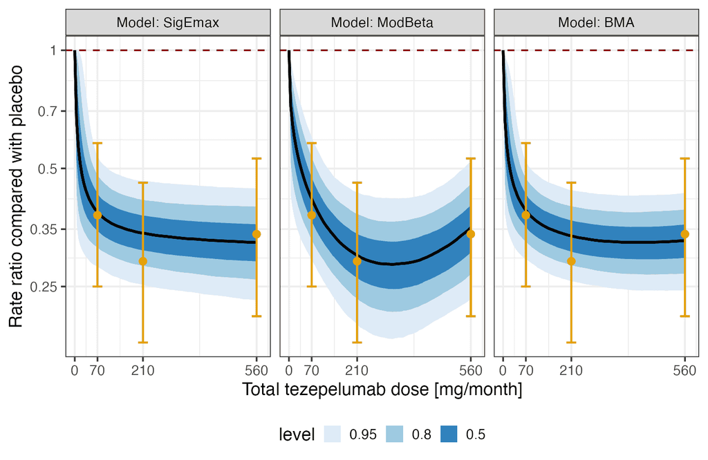

# Hands-on exercises: dose finding

# Bayesian Mixed Models for Repeated Measures

## Hypothetical dose finding study, N=200

Continuous outcome measured at baseline & weeks 2, 4, 8, 12

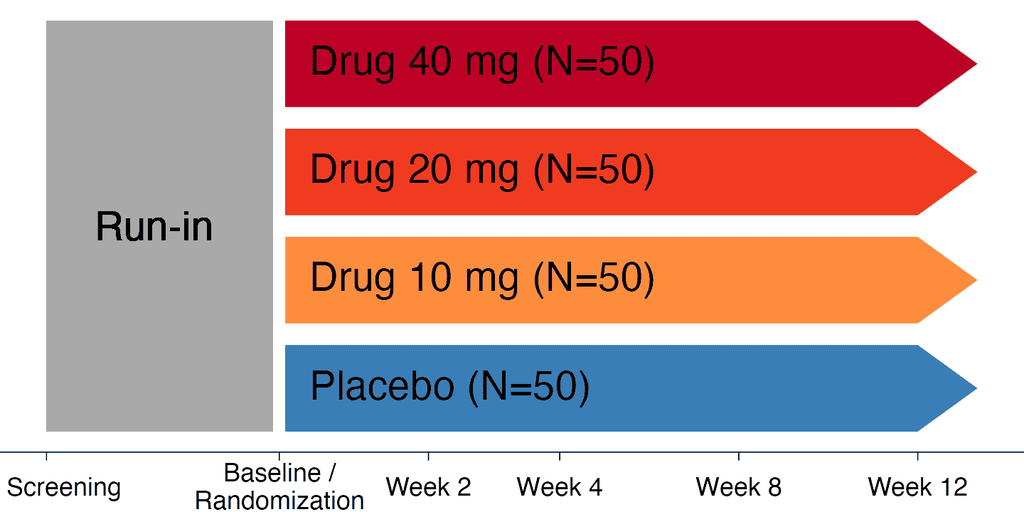

## Overview and Analysis Goals

- Mixed Effects Model for Repeated Measures (MMRM) commonly used for longitudinal data (each patient measured at multiple visits)
- Direct likelihood analysis that can address **hypothetical estimand of all patients completing** the study on treatment without doing missing data imputation first
- Commonly no structure assumed for correlations between visits and different variance allowed for different visits (to avoid unnecessary assumptions)
- Convergence issues with REML fit common, especially for small sample sizes, which is alleviated by Bayesian inference with (weakly-)informative priors
- Bayesian approach allows us to incorporate prior information and historical data, which is very interesting for Phase I studies
- `brms` lets us easily add more components & structure to the model

## What do our data look like?

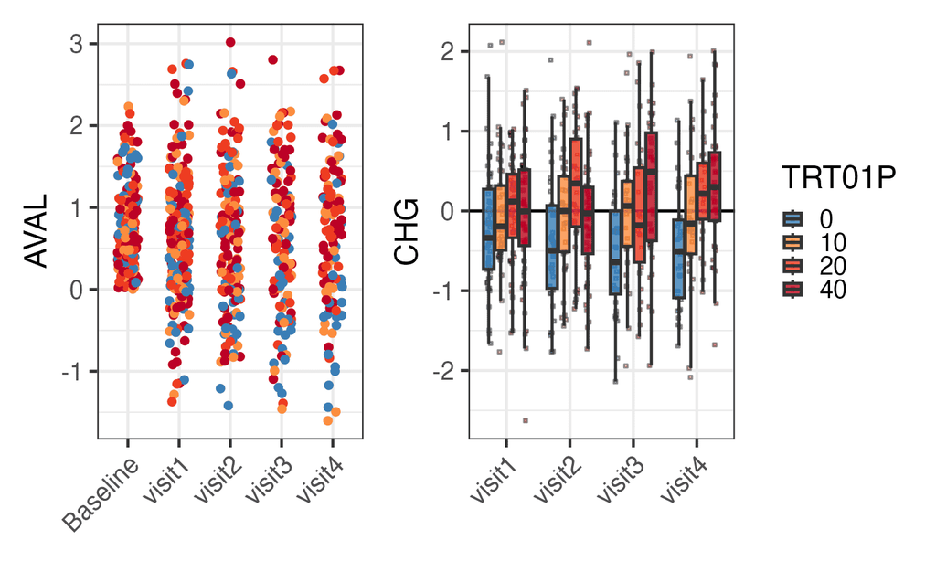

## Analysis Data Model (ADaM) Basic Data Structure (BDS)

| USUBJID | TRT01P | AVISIT | ADY | AVAL | CHG | BASE |
| --- | --- | --- | --- | --- | --- | --- |
| 3 | 20 | visit1 | 14 | 1.36 | 0.58 | 0.78 |
| 3 | 20 | visit2 | 28 | 1.17 | 0.40 | 0.78 |
| 3 | 20 | visit3 | 56 | −0.37 | −1.14 | 0.78 |
| 3 | 20 | visit4 | 84 | 1.35 | 0.58 | 0.78 |
| 9 | 40 | visit1 | 14 | 0.99 | 0.89 | 0.11 |
| 9 | 40 | visit2 | 28 | 1.34 | 1.23 | 0.11 |
| 9 | 40 | visit3 | 56 | −1.09 | −1.20 | 0.11 |
| 9 | 40 | visit4 | 84 | 1.16 | 1.05 | 0.11 |
| 13 | 40 | visit1 | 14 | 2.40 | 0.50 | 1.90 |
| 13 | 40 | visit2 | 28 | 1.92 | 0.02 | 1.90 |

> Patients can miss visits or drop-out of the study prior to the final visit.

## Model Specification: Informal (popular choice)

Fixed effects:

- baseline (pre-treatment) value of the endpoint
- visit as a factor
- treatment as a factor
- treatment by visit interaction
- visit by baseline value interaction

Random effects:

- Random subject effect on the visit main effect
- … or equivalently correlated residual error terms within subjects

## Model Specification: Formal

Formally, let us assume that there are $V$ visits. We assume that the $V$-dimensional response $\boldsymbol{Y}_i$ for patient $i$ satisfies
$$\boldsymbol{Y}_i = \boldsymbol{X}_i \boldsymbol{\beta} + \boldsymbol{Z}_i \boldsymbol{b}_i + \boldsymbol{\epsilon}_i$$

with $\boldsymbol{b}_i \sim \text{MVN}(\boldsymbol{0}, \boldsymbol{D})$ and $\boldsymbol{\epsilon}_i \sim \text{MVN}(\boldsymbol{0}, \boldsymbol{\Sigma})$, where $\boldsymbol{\Sigma}$ is a diagonal matrix. This implies
$$\boldsymbol{Y}_i \sim \text{MVN}(\boldsymbol{X}_i \boldsymbol{\beta}, \boldsymbol{V}_i),$$
where $\boldsymbol{V}_i = \boldsymbol{Z}_i \boldsymbol{D} \boldsymbol{Z}_i^T + \boldsymbol{\Sigma}$. Model the correlated $Y_{ij}$ either by

1. marginalizing out random effects & account for them with correlated residual errors (residual covariance matrix $V_i$), or
2. conditionally on (V-dimensional) random effects $\boldsymbol{b}_i$ with residual errors $\boldsymbol{\epsilon}_i$ independent (once we condition on $\boldsymbol{b}_i$).

## MMRMs in SAS

Widely-used high-quality reference implementation

```sas
PROC MIXED DATA=simulated_data;
  CLASS TRT01P AVISIT USUBJID;
  MODEL CHG ~ TRT01P AVISIT BASE TRT01P*AVISIT AVISIT*BASE
    / SOLUTION DDFM=KR ALPHA = 0.05;
  REPEATED AVISIT / TYPE=UN SUBJECT = USUBJID R Rcorr GROUP=TRT01P;
  LSMEANS TRT01P*AVISIT / DIFFS PDIFF CL OM E;
RUN;
```

## MMRMs with the `mmrm` R package

Fit the model in R in a frequentist framework

```r
library(mmrm)
mmrm_fit <- mmrm(
  formula = CHG ~ TRT01P + AVISIT + BASE + AVISIT:TRT01P +
    AVISIT:BASE + us(AVISIT | TRT01P / USUBJID),
  method = "Kenward-Roger",
  vcov = "Kenward-Roger-Linear", # to match SAS
  data = mutate(simulated_data, USUBJID=factor(USUBJID))
)
```

Refer to https://openpharma.github.io/mmrm.

## Motivation Forward Difference Parametrization

We would like to put priors on the differences from visit to visit

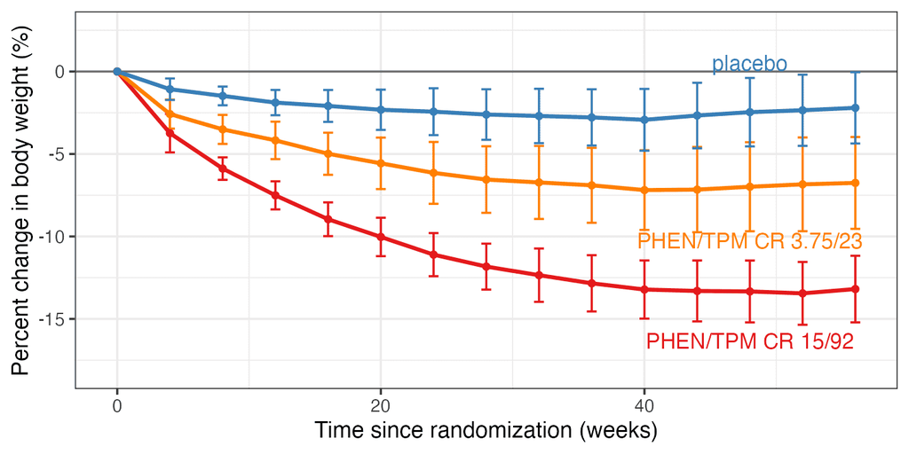

## Difference contrasts in R

Setup forward difference contrasts for changes between visits:

```r
contrasts(simulated_data$AVISIT) <- MASS::contr.sdif
```

Hard to interpret the contrast matrix directly:

```r
contrasts(simulated_data$AVISIT) |> MASS::fractions()
```

```
       visit2-visit1 visit3-visit2 visit4-visit3
visit1 -3/4          -1/2          -1/4
visit2  1/4          -1/2          -1/4
visit3  1/4           1/2          -1/4
visit4  1/4           1/2           3/4
```

Learn more about contrasts: https://bbolker.github.io/mixedmodels-misc/notes/contrasts.pdf

## What do these contrasts mean?

Inverting the contrast matrix reveals the dummy variables’ interpretation:

```r
# add the intercept
cmat <- cbind("Intercept" = 1, contrasts(simulated_data$AVISIT))
# compute the inverse matrix
solve(cmat) |> MASS::fractions()
```

```
              visit1 visit2 visit3 visit4
Intercept     1/4    1/4    1/4    1/4
visit2-visit1  -1      1      0      0
visit3-visit2   0     -1      1      0
visit4-visit3   0      0     -1      1
```

## MMRMs in `brms`

```r
mmrm_model1 <- bf(
  CHG ~ 1 + AVISIT + BASE + BASE:AVISIT + TRT01P + TRT01P:AVISIT
    + unstr(time = AVISIT, gr = USUBJID),
  sigma ~ 1 + AVISIT + TRT01P + AVISIT:TRT01P
)
```

```r
mmrm_prior1 <- prior(normal(0, 2), class=Intercept) +
    prior(normal(0, 1), class=b) +
    prior(normal(0, log(10.0)/1.64), class=Intercept, dpar=sigma) +
    prior(normal(0, log(2.0)/1.64), class=b, dpar=sigma) +
    prior(lkj(1), class=cortime)
```

```r
fit_mmrm1 <- brm(
  formula = mmrm_model1, data = simulated_data, prior = mmrm_prior1, ...
)
```

Note that a single **correlation matrix** is estimated while the **covariance** varies as per the `sigma` model.

## Expected marginal (least-squares) means

```r
emm2 <- emmeans(fit_mmrm1, ~ TRT01P | AVISIT, weights="proportional")
```

```
AVISIT = visit1:
 TRT01P  emmean lower.HPD upper.HPD
 0      -0.1980  -0.40046   0.00315
 10     -0.0311  -0.23097   0.16545
 20      0.0295  -0.15239   0.23558
 40     -0.0409  -0.24827   0.15353

AVISIT = visit4:
 TRT01P  emmean lower.HPD upper.HPD
 0      -0.4309  -0.68571  -0.17626
 10     -0.0280  -0.34350   0.26386
 20      0.2526   0.00595   0.52464
 40      0.3474   0.08482   0.60094

Point estimate displayed: median
HPD interval probability: 0.95
```

To work with MCMC samples of the expected marginal means & to summarize them exactly as we want (e.g. quantile credible intervals instead of highest posterior density intervals) we can use:

```r
emm2 |> as.mcmc() |> summarize_draws()
```

## Expected Marginal Contrasts per Visit

```r
contrast(emm2, adjust="none", method="trt.vs.ctrl", ref="TRT01P0")
```

```
AVISIT = visit1:
 contrast           estimate lower.HPD upper.HPD
 TRT01P10 - TRT01P0    0.166  -0.10316     0.459
 TRT01P20 - TRT01P0    0.227  -0.05206     0.508
 TRT01P40 - TRT01P0    0.157  -0.12485     0.438

AVISIT = visit4:
 contrast           estimate lower.HPD upper.HPD
 TRT01P10 - TRT01P0    0.400   0.00171     0.798
 TRT01P20 - TRT01P0    0.677   0.32089     1.050
 TRT01P40 - TRT01P0    0.776   0.37929     1.111

Point estimate displayed: median
HPD interval probability: 0.95
```

`as.mcmc()` to work with MCMC samples of the difference, e.g.

```r
contrast(emm2, adjust="none", method="trt.vs.ctrl", ref="TRT01P0") |> as.mcmc()
```

## Monotonic Effects Across Ordered Factor Levels

```r
mmrm_model2 <- bf(
  CHG ~ 1 + AVISIT + mo(TRT01P) + BASE + mo(TRT01P):AVISIT
    + BASE:AVISIT + unstr(time = AVISIT, gr = USUBJID),
  sigma ~1 + AVISIT + mo(TRT01P) + mo(TRT01P):AVISIT
)
```

For category $c=0,\ldots,(\text{categories}-1) = C-1$, the monotonic term is
$$\text{coefficient} \times (C-1) \times \sum_{k=1}^{c} \zeta_k$$

- $\zeta_k \in [0, 1]$ is the percent increase and is subject to the constraint $\sum_{k=1}^{C-1} \zeta_k = 1$
- $\text{coefficient}$ is the mean change between adjacent categories

For more details see the respective vignette:  
https://paulbuerkner.com/brms/articles/brms_monotonic.html

```r
fit_mmrm2 <- brm(formula = mmrm_model2,
                 data = simulated_data |> mutate(TRT01P=ordered(TRT01P)), prior = mmrm_prior1, ...)
```

## Results from different MMRMs

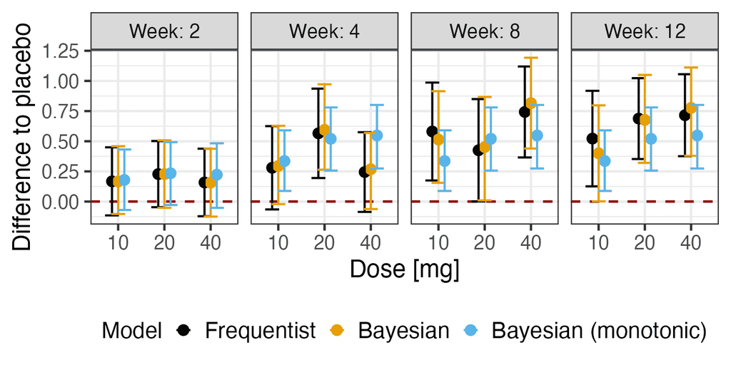

## MMRMs: Outlook

In the online case study on http://opensource.nibr.com/bamdd you additionally find:

- Data and full code
- More on estimands, parametrization, contrasts & priors
- Estimating average differences across visits
- Meta-analytic combined (MAC) using historical data
- Robustifying MAC via a “slab-and-spike”-type prior
- Non-linear functions over time & doses in MMRMs
- Exercises

# Longitudinal data

## Longitudinal Data: Background

- Example: simulated study of a drug for the treatment of Psoriasis
- 112 patients, 59 randomized to placebo, 53 to drug.
- Efficacy was assessed using the Psoriasis Area and Severity Index (PASI), a numerical score which measures the severity and extent of psoriasis (0: no disease, 72: maximum).
- Assessed at baseline and 7 post-baseline timepoints.

## Longitudinal Data: Illustration

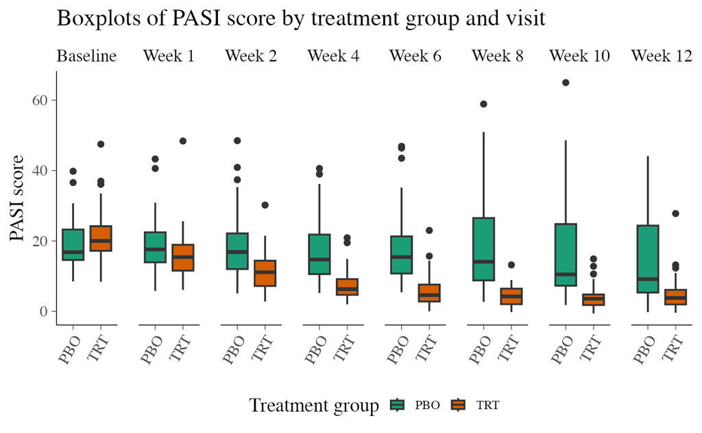

## Longitudinal Data: Key Variables

```
# A tibble: 10 × 6
      CHG  BASE TRT01P AVISIT  AVISITN SUBJID
    <dbl> <dbl> <fct>  <fct>     <dbl>  <dbl>
 1 -2.2    16   PBO    Week 1        1      1
 2 -0.5    16   PBO    Week 2        2      1
 3  4.7    16   PBO    Week 4        4      1
 4  7.3    16   PBO    Week 6        6      1
 5 32.1    16   PBO    Week 8        8      1
 6 10      16   PBO    Week 10      10      1
 7 20.7    16   PBO    Week 12      12      1
 8  3.4    20.3 TRT    Week 1        1      2
 9  1.2    20.3 TRT    Week 2        2      2
10  0.600  20.3 TRT    Week 4        4      2
```

…

## Longitudinal Data: Mean Model

```r
fit_long_mean <- brm(
  CHG ~ BASE + TRT01P * AVISIT + (1 | SUBJID),
  data = pasi_data, seed = 2454
)
fit_long_mean <- add_criterion(fit_long_mean, "loo")
```

Total elapsed fitting time (seconds):

```r
sum(rstan::get_elapsed_time(fit_long_mean$fit))
```

```
[1] 3.459
```

## Mean Model: Posterior predictive checks

```r
pp_check(fit_long_mean)
```

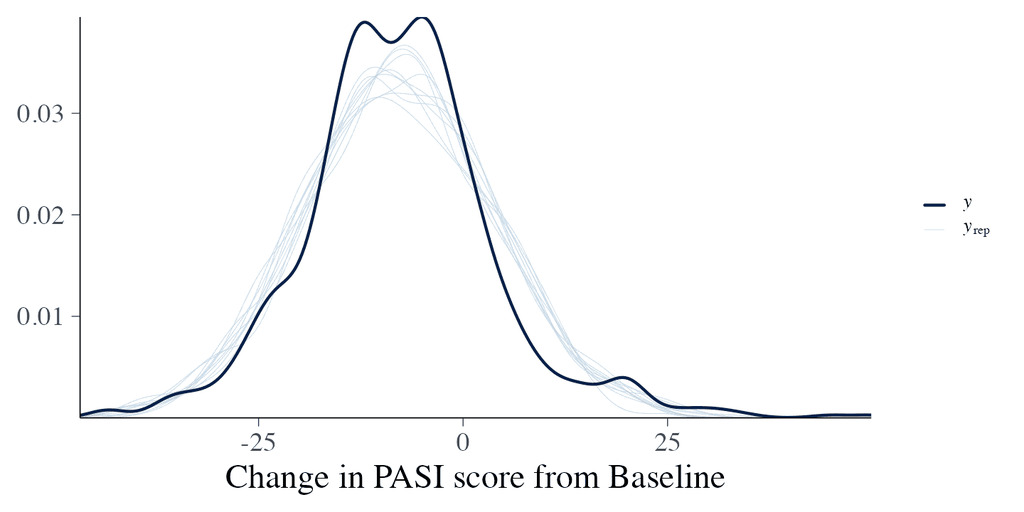

- `pp_check` in `brms` performs posterior predictive checks with the help of the `bayesplot` package (shows `dens_overlay` by default).
  - Can also be called with type `loo_pit_qq` (probability integral transformation). In an ideal model fit, the resulting PIT-transformed values would be uniformly distributed: i.e. the blue points and dashed lines would align with the distribution function of a Uniform(0,1) variable (solid line). See [chapter 12 of BAMDD](https://opensource.nibr.com/bamdd/src/02g_longitudinal.html#assessing-model-fit) for details.

## Mean Model: LOO-CV results

```r
loo(fit_long_mean)
```

```
Computed from 4000 by 684 log-likelihood matrix.

         Estimate   SE
elpd_loo  -2285.7 33.1
p_loo       101.9  9.5
looic      4571.4 66.3
------
MCSE of elpd_loo is NA.
MCSE and ESS estimates assume MCMC draws (r_eff in [0.4, 1.8]).

Pareto k diagnostic values:
                         Count Pct.    Min. ESS
(-Inf, 0.7]   (good)     681   99.6%   103
   (0.7, 1]   (bad)        3    0.4%   <NA>
   (1, Inf)   (very bad)   0    0.0%   <NA>
See help('pareto-k-diagnostic') for details.
```

- While this is quick, is this what we are interested in?
  - If we’re interested in the prediction for a new (unseen) patient, we should be running leave-one-patient-out CV (not leave-one-observation-out)…  
    See `kfold_split_grouped` in the `loo` package.
  - For the E<sub>max</sub> model data: not possible (IPD needed!)

## Mean Model: Visualization of effects

```r
conditional_effects(fit_long_mean, "AVISIT:TRT01P")
```

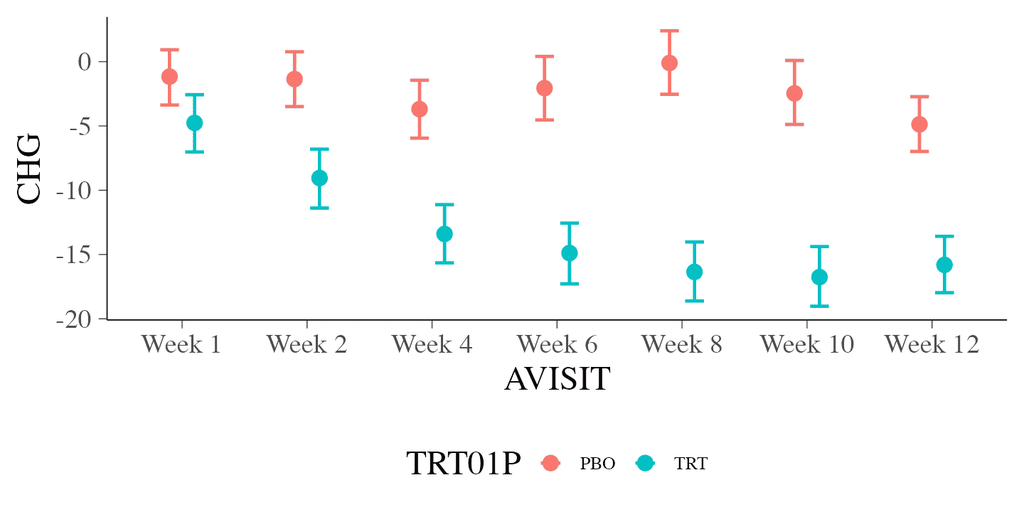

- By default, numeric variables will be conditionalized by using their means and factors will get their first level assigned.
- We might be interested in the effect integrated out over a population $\rightarrow$ `emmeans`
  - See longitudinal data exercise 1 in [BAMDD Chapter 12](https://opensource.nibr.com/bamdd/src/02g_longitudinal.html#exercises)

## Longitudinal Data: Linear Model

```r
fit_long_lin <- brm(
  CHG ~ BASE + TRT01P * AVISITN + (1 | SUBJID),
  data = pasi_data, seed = 2454
)
fit_long_lin <- add_criterion(fit_long_lin, "loo")
```

Total elapsed fitting time:

```r
sum(rstan::get_elapsed_time(fit_long_lin$fit))
```

```
[1] 2.883
```

## Linear Model: Summary

```r
summary(fit_long_lin)
```

```
 Family: gaussian
  Links: mu = identity
Formula: CHG ~ BASE + TRT01P * AVISITN + (1 | SUBJID)
   Data: pasi_data (Number of observations: 684)

Multilevel Hyperparameters:
~SUBJID (Number of levels: 112)
              Estimate Est.Error l-95% CI u-95% CI Rhat Bulk_ESS Tail_ESS
sd(Intercept)     5.21      0.45     4.41     6.15 1.00     1358     2336

Regression Coefficients:
                  Estimate Est.Error l-95% CI u-95% CI Rhat Bulk_ESS Tail_ESS
Intercept            13.11      1.78     9.55    16.53 1.00     1567     2375
BASE                 -0.70      0.08    -0.85    -0.54 1.00     1502     2233
TRT01PTRT            -6.10      1.34    -8.74    -3.43 1.00     1497     2504
AVISITN              -0.22      0.09    -0.40    -0.04 1.00     3550     3397
TRT01PTRT:AVISITN    -0.72      0.13    -0.97    -0.47 1.00     3360     3063

Further Distributional Parameters:
      Estimate Est.Error l-95% CI u-95% CI Rhat Bulk_ESS Tail_ESS
sigma     6.52      0.19     6.15     6.91 1.00     4605     3086
```

## Linear Model: Visualization of effects

```r
conditional_effects(fit_long_lin, "AVISITN:TRT01P")
```

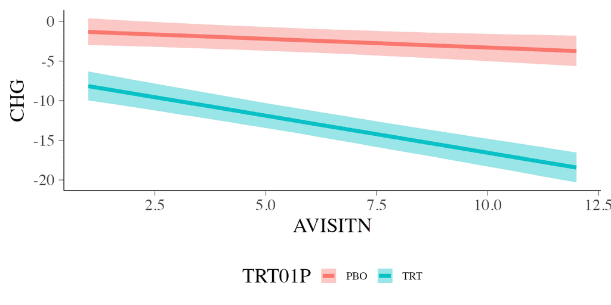

## Longitudinal Data: Linear Model with Varying Slopes

```r
fit_long_lin_vs <- brm(
  CHG ~ BASE + TRT01P * AVISITN + (1 + AVISITN | SUBJID),
  data = pasi_data, seed = 2454
)
fit_long_lin_vs <- add_criterion(fit_long_lin_vs, "loo")
```

Total elapsed fitting time:

```r
sum(rstan::get_elapsed_time(fit_long_lin_vs$fit))
```

```
[1] 8.488
```

## Linear Model: Summary

```r
summary(fit_long_lin_vs)
```

```
 Family: gaussian
  Links: mu = identity
Formula: CHG ~ BASE + TRT01P * AVISITN + (1 + AVISITN | SUBJID)
   Data: pasi_data (Number of observations: 684)

Multilevel Hyperparameters:
~SUBJID (Number of levels: 112)
                       Estimate Est.Error l-95% CI u-95% CI Rhat Bulk_ESS Tail_ESS
sd(Intercept)              5.26      0.53     4.28     6.32 1.00     1393     2805
sd(AVISITN)                1.10      0.09     0.94     1.28 1.00      708     1345
cor(Intercept,AVISITN)    -0.54      0.09    -0.70    -0.35 1.01      489      928

Regression Coefficients:
                  Estimate Est.Error l-95% CI u-95% CI Rhat Bulk_ESS Tail_ESS
Intercept             9.26      1.71     5.94    12.66 1.00     1294     1997
BASE                 -0.50      0.08    -0.65    -0.35 1.00     1052     1954
TRT01PTRT            -6.46      1.22    -8.92    -4.00 1.00     1883     2263
AVISITN              -0.24      0.16    -0.55     0.08 1.00      937     1943
TRT01PTRT:AVISITN    -0.72      0.24    -1.18    -0.24 1.00      818     1626

Further Distributional Parameters:
      Estimate Est.Error l-95% CI u-95% CI Rhat Bulk_ESS Tail_ESS
sigma     4.67      0.15     4.38     4.98 1.00     3159     3212
```

## Linear Model with Varying Slopes: Visualization of effects

```r
conditional_effects(fit_long_lin_vs, "AVISITN:TRT01P")
```

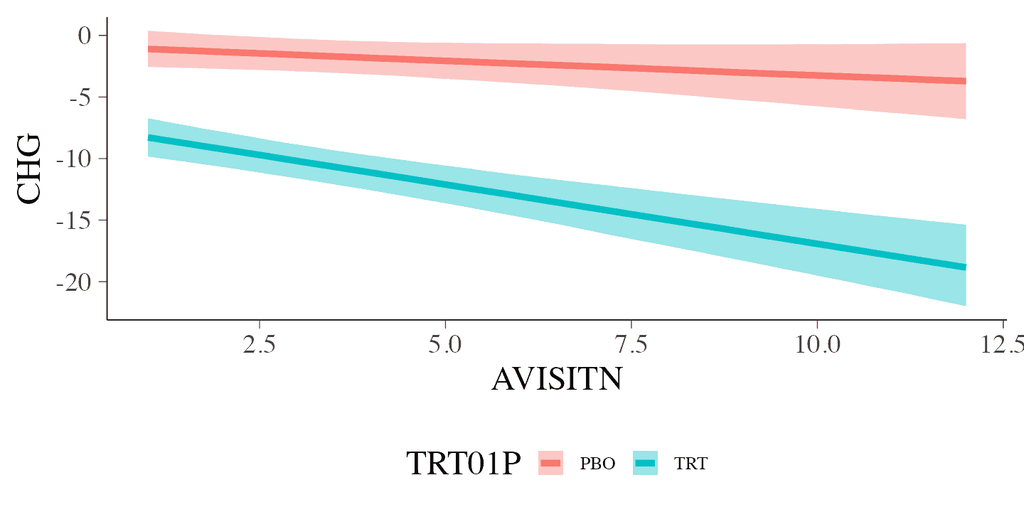

## Model Comparison

```r
loo_compare(fit_long_lin, fit_long_lin_vs)
```

```
           model elpd_diff se_diff p_worse diag_diff       diag_elpd
 fit_long_lin_vs       0.0     0.0      NA           35 k_psis > 0.7
    fit_long_lin    -174.0    20.5    1.00            3 k_psis > 0.7
```

## Longitudinal Data: Monotonic Model

```r
fit_long_mo <- brm(
  CHG ~ BASE + TRT01P * mo(AVISITN) +
    (1 + mo(AVISITN) | SUBJID),
  data = pasi_data, seed = 24543
)
fit_long_mo <- add_criterion(fit_long_mo, "loo")
```

Total elapsed fitting time:

```r
sum(rstan::get_elapsed_time(fit_long_mo$fit))
```

```
[1] 29.755
```

## Monotonic Model: Visualization of effects

```r
conditional_effects(fit_long_mo, "AVISITN:TRT01P")
```

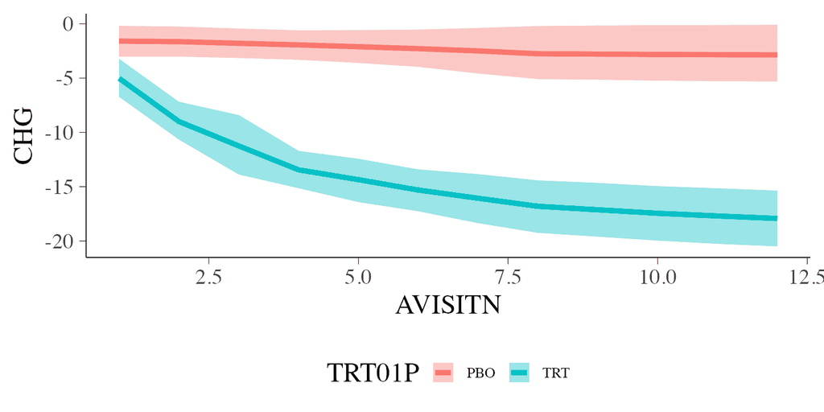

## Model Comparison

```r
loo_compare(fit_long_lin_vs, fit_long_mo)
```

```
           model elpd_diff se_diff p_worse diag_diff       diag_elpd
     fit_long_mo       0.0     0.0      NA           37 k_psis > 0.7
 fit_long_lin_vs     -91.5    11.7    1.00           35 k_psis > 0.7
```

## Longitudinal Data: Quadratic Model

```r
fit_long_quad <- brm(
  CHG ~ BASE + TRT01P * (AVISITN + I(AVISITN^2)) +
    (1 + AVISITN + I(AVISITN^2) | SUBJID),
  data = pasi_data, seed = 245124
)
fit_long_quad <- add_criterion(fit_long_quad, "loo")
```

Total elapsed fitting time:

```r
sum(rstan::get_elapsed_time(fit_long_quad$fit))
```

```
[1] 40.665
```

## Quadratic Model: Visualization of effects

```r
conditional_effects(fit_long_quad, "AVISITN:TRT01P")
```

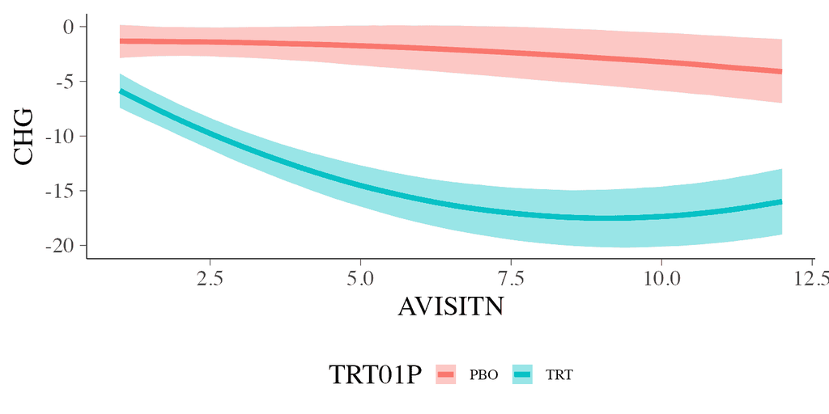

## Longitudinal Data: Centering the time variable

Non-centered variables are often highly correlated with their square

```r
cor(pasi_data$AVISITN, pasi_data$AVISITN^2)
```

```
[1] 0.9734303
```

Centering can be done around any central value. Here we use 6 because this is the average week in the study

```r
pasi_data <- pasi_data |>
  mutate(AVISITN_c = AVISITN - 6)
```

After centering, the correlation is drastically reduced

```r
cor(pasi_data$AVISITN_c, pasi_data$AVISITN_c^2)
```

```
[1] 0.2548532
```

## Longitudinal Data: Centered Quadratic model

```r
fit_long_quad_c <- brm(
  CHG ~ BASE + TRT01P * (AVISITN_c + I(AVISITN_c^2)) +
    (1 + AVISITN_c + I(AVISITN_c^2) | SUBJID),
  data = pasi_data, seed = 24547
)
fit_long_quad_c <- add_criterion(fit_long_quad_c, "loo")
```

Total elapsed fitting time:

```r
sum(rstan::get_elapsed_time(fit_long_quad_c$fit))
```

```
[1] 13.838
```

## Centered Quadratic Model: Visualization of effects

```r
conditional_effects(fit_long_quad_c, "AVISITN_c:TRT01P")
```

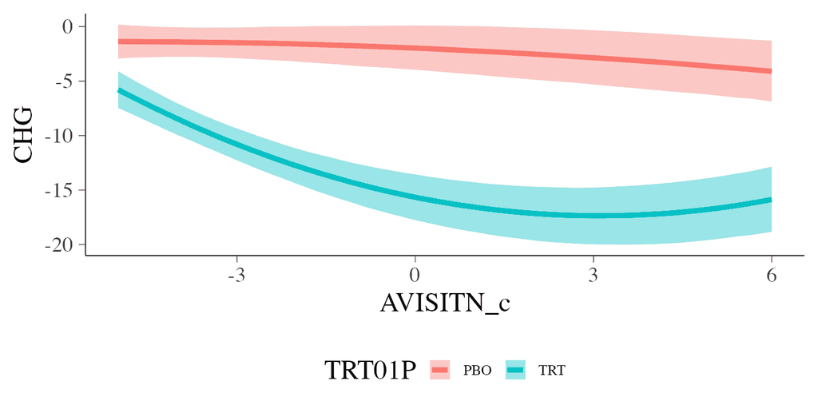

## Model Comparison

```r
loo_compare(fit_long_mo, fit_long_quad_c)
```

```
           model elpd_diff se_diff p_worse diag_diff       diag_elpd
     fit_long_mo       0.0     0.0      NA           37 k_psis > 0.7
 fit_long_quad_c     -17.8     9.8    0.96           41 k_psis > 0.7
```

## Longitudinal Data: Gaussian Process Model

```r
fit_long_gp <- brm(
  CHG ~ BASE + gp(AVISITN_c, by = TRT01P, k=9) +
    (1 + (AVISITN_c + I(AVISITN_c^2)) | SUBJID),
  data = pasi_data, seed = 32454,
  control = list(adapt_delta = 0.95)
)
fit_long_gp <- add_criterion(fit_long_gp, "loo")
```

Total elapsed fitting time:

```r
sum(rstan::get_elapsed_time(fit_long_gp$fit))
```

```
[1] 87.535
```

## Gaussian Process Model: LOO-CV results

```r
loo(fit_long_gp)
```

```
Computed from 4000 by 684 log-likelihood matrix.

         Estimate   SE
elpd_loo  -2042.9 35.3
p_loo       191.3 15.6
looic      4085.9 70.7
------
MCSE of elpd_loo is NA.
MCSE and ESS estimates assume MCMC draws (r_eff in [0.3, 1.7]).

Pareto k diagnostic values:
                         Count Pct.    Min. ESS
(-Inf, 0.7]   (good)     644   94.2%   121
   (0.7, 1]   (bad)       35    5.1%   <NA>
   (1, Inf)   (very bad)   5    0.7%   <NA>
See help('pareto-k-diagnostic') for details.
```

## Gaussian Process Model: Visualization of effects

```r
conditional_effects(fit_long_gp, "AVISITN_c:TRT01P")
```

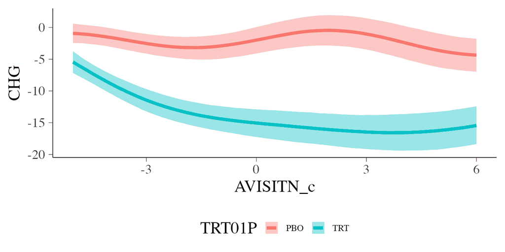

## Model Comparison

```r
loo_compare(fit_long_quad_c, fit_long_gp)
```

```
           model elpd_diff se_diff p_worse diag_diff       diag_elpd
     fit_long_gp       0.0     0.0      NA           40 k_psis > 0.7
 fit_long_quad_c     -13.9     6.3    0.99           41 k_psis > 0.7
```

Recall that model comparisons may not be trustworthy.

## Longitudinal Data: Gaussian Process AR1 Model

```r
fit_long_gp_ar <- brm(
  CHG ~ BASE + gp(AVISITN_c, by = TRT01P, k=9) +
    ar(AVISITN_c, gr = SUBJID, p = 1) +
    (1 + (AVISITN_c + I(AVISITN_c^2)) | SUBJID),
  data = pasi_data, seed = 24235,
  iter = 4000, warmup = 1000,
  control = list(adapt_delta = 0.95)
)
fit_long_gp_ar <- add_criterion(fit_long_gp_ar, "loo")
```

Total elapsed fitting time:

```r
sum(rstan::get_elapsed_time(fit_long_gp_ar$fit))
```

```
[1] 180.274
```

## Gaussian Process AR1 Model: Autocorrelation results

Some autocorrelation may be present:

```r
posterior_summary(fit_long_gp_ar, variable = "ar") |>
  round(3)
```

```
      Estimate Est.Error  Q2.5 Q97.5
ar[1]    0.384     0.122 0.159  0.63
```

A more formal model comparison may be theoretically advantageous but given that we add only a single parameter (the AR1 effect), we should probably gain more than we loose by including it.

## Gaussian Process AR1 Model: Visualization of effects

```r
conditional_effects(fit_long_gp_ar, "AVISITN_c:TRT01P")
```

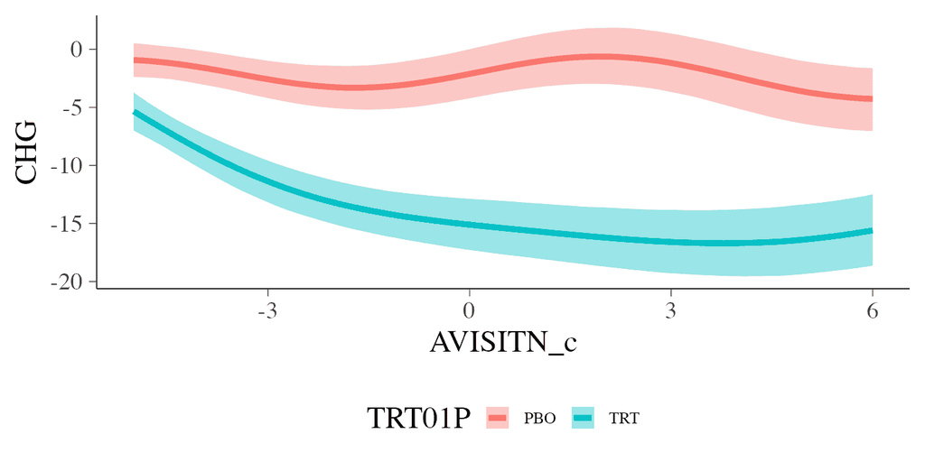

# Time-to-Event analysis

## Overview and Analysis Goals

- Oncology late phase trial to evaluate efficacy of an active drug given in addition to two similar standard of care (SoC-A and SoC-B), which vary geographically
- A total of 4 trial arms studied combining
  - SoC-A & active vs SoC-A
  - SoC-B & active vs SoC-B
- Analysis needs to account for:
  - SoC-A and SoC-B are known for similar efficacy
  - Active drug efficacy is expected to be consistent with SoC-A and SoC-B  
    $\Rightarrow$ interest in average treatment effect

> Key analysis goal: Reflect prior knowledge on similarity and increase efficiency in estimating average treatment effect $\Rightarrow$ control model *parametrization*.

## Simulated Data Set

First few rows of the simulated dataset:

|  | y | event | trt | soc | arm |
| --- | --- | --- | --- | --- | --- |
| 1 | 7.70 | 0 | ctl | ChA | ctlChA |
| 2 | 0.10 | 0 | act | ChA | actChA |
| 3 | 4.75 | 0 | ctl | ChA | ctlChA |
| 4 | 2.75 | 0 | act | ChA | actChA |
| 5 | 3.61 | 1 | ctl | ChA | ctlChA |
| 6 | 0.94 | 1 | act | ChA | actChA |
| 7 | 0.26 | 1 | ctl | ChA | ctlChA |
| 8 | 9.21 | 1 | act | ChA | actChA |
| 9..199 |  |  |  |  |  |
| 200 | 11.81 | 0 | act | ChA | actChA |

## Contrasts Define Model Parametrization

Overall mean (intercept):
$$\mu = \frac{1}{4}( \mu_{actChA} + \mu_{ctlChA} + \mu_{actChB} + \mu_{ctlChB} )$$

Average difference between the active and control arms:
$$\delta_{avg.diff} = \frac{1}{2} ( [\mu_{actChA} - \mu_{ctlChA}] + [ \mu_{actChB} - \mu_{ctlChB}] )$$

Half of the difference in treatment effect between the two SOC:
$$\delta_{effect} = \frac{1}{2}( [ \mu_{actChA} - \mu_{ctlChA}] - [ \mu_{actChB} - \mu_{ctlChB}] )$$

Difference between the two control arms:
$$\delta_{control} = - \mu_{ctlChA} + \mu_{ctlChB}$$

## Contrasts Defined Via Inverse Mapping

First specify the groups as a function of the contrasts:

```r
cc_inv
```

```
              arm
contrast       actChA ctlChA actChB ctlChB
  intercept     1/4    1/4    1/4    1/4
  effectAvg     1/2   -1/2    1/2   -1/2
  deltaEffect   1/2   -1/2   -1/2    1/2
  deltaControl    0     -1      0      1
```

## Contrasts: Contrast Matrix

Then invert the matrix to get the actual contrast matrix:

```r
cc <- solve(cc_inv)
```

```
       intercept effectAvg deltaEffect deltaControl
actChA    1       1/2         1        -1/2
ctlChA    1      -1/2         0        -1/2
actChB    1       1/2        -1         1/2
ctlChB    1      -1/2         0         1/2
```

To use the custom contrasts, we have to assign these to the respective `factor` column of the data (but exclude the overall intercept):

```r
contrasts(sim$arm) <- cc[, -1]
```

## The Weibull Family in `brms`

When using family `weibull` in brms, we are modeling the mean time $\mu$ until the event, **not** the hazard function (see the [brms vignette on families](https://paulbuerkner.com/brms/articles/brms_families.html) for parametrization details).

Parameterize as mean time $\mu$ and shape $\alpha$ such that, with scale $s = \mu / \Gamma(1 + 1/\alpha)$:

$$\text{Weibull}(t) = \frac{\alpha}{s} \left( \frac{t}{s}
\right)^{\alpha-1} \, \exp\left(-\left(\frac{t}{s}\right)^\alpha\right)$$

- This is an accelerated failure time model since the survivor function has the property of $S_i(t) = S_{\text{weibull}}(t/\mu_i)$.
- When using a log linear model on $\mu$
  - the intercept is the $\log$-mean event time
  - regression coefficients are interpretable as speedup/slowdown of the process

## Specify `brms` Weibull Model

```r
model_weibull1 <- bf(y | cens(1-event) ~ 1 + arm,
                     family=weibull())

prior_weibull1 <-
  prior(normal(meanInter, log(4)/1.64), class=Intercept) +
  prior(normal(0, sdEffect), coef=armeffectAvg) +
  prior(normal(0, sdDeltaEffect), coef=armdeltaEffect) +
  prior(normal(0, sdDeltaControl), coef=armdeltaControl) +
  prior(gamma(0.1, 0.1), class=shape)
```

We use variable symbols like `meanInter`, `sdEffect` and the like, which need to be defined with `stanvars`,

```r
stanvars_weibull1 <-
  stanvar(-log(log(2)/8), name = "meanInter") +
  stanvar(log(2)/1.64, name = "sdEffect") +
  stanvar(log(1.25)/1.64, name = "sdDeltaEffect") +
  stanvar(log(1.25)/1.64, name = "sdDeltaControl")
```

This avoids model recompilation when changing priors.

## Fit `brms` Weibull Model

```r
fit_weibull1 <- brm(
  formula = model_weibull1,
  data = sim,
  prior = weibull_prior1,
  stanvars = stanvars_weibull1,
  seed=345665
)
```

## Model Summary

```r
summary(fit_weibull1)
```

```
 Family: weibull
  Links: mu = log
Formula: y | cens(1 - event) ~ 1 + arm
   Data: sim (Number of observations: 200)

Regression Coefficients:
                Estimate Est.Error l-95% CI u-95% CI Rhat Bulk_ESS Tail_ESS
Intercept           2.16      0.12     1.95     2.41 1.00     3672     2803
armeffectAvg        0.26      0.18    -0.10     0.61 1.00     4707     2934
armdeltaEffect      0.01      0.11    -0.20     0.21 1.00     4316     2583
armdeltaControl     0.06      0.12    -0.18     0.30 1.00     4717     2917

Further Distributional Parameters:
      Estimate Est.Error l-95% CI u-95% CI Rhat Bulk_ESS Tail_ESS
shape     0.97      0.08     0.83     1.13 1.00     3243     2880
```

## Posterior Predictive Checks

```r
pp_check(
  fit_weibull1, type = "km_overlay",
  ndraws = 100
)
```

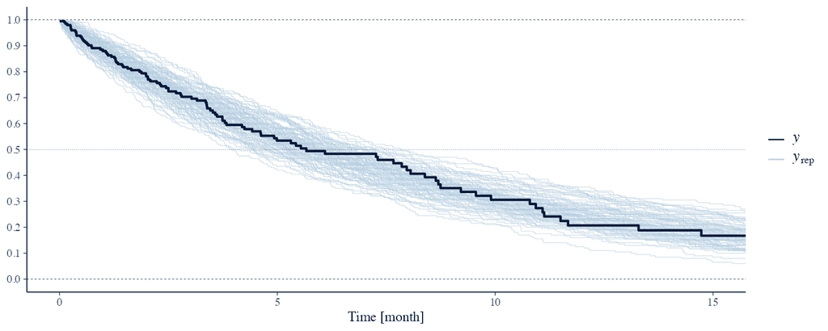

The model predictions assume no censoring

## Including Historical Data

Suppose we have historical data available from a previous study where only SoC was applied. This extends our control group data:

|  | y | event | arm | hist1 |
| --- | --- | --- | --- | --- |
| 1 | 3.64 | 1 | ctlChA | 1 |
| 2 | 8.39 | 1 | ctlChA | 1 |
| 3 | 6.46 | 0 | ctlChA | 1 |
| 4 | 3.18 | 1 | ctlChA | 1 |
| 5 | 1.29 | 1 | ctlChA | 1 |
| 6 | 5.90 | 0 | ctlChA | 1 |
| 7 | 1.99 | 0 | ctlChA | 1 |
| 8 | 2.66 | 1 | ctlChA | 1 |
| 9..399 |  |  |  |  |
| 400 | 1.03 | 1 | ctlChA | 1 |

## Including Historical Data: Analysis Code

- Approximation of a meta-analytic-approach (MAP) by allowing a deviation for the historical data set on the overall intercept through an indicator covariate
- Use of a heavy tailed Student-t prior resembles heavy-tailed MAP random effect

```r
sim_comb <- bind_rows(sim, hdata1)
contrasts(sim_comb$arm) <- cc[, -1]

model_weibull2 <- bf(
  y | cens(1-event) ~ 1 + arm + hist1,
  family=weibull()
)

prior_weibull2 <- prior_weibull1 +
  prior(student_t(6, 0, sdHist), coef = hist1)

stanvars_weibull2 <- stanvars_weibull1 +
  stanvar(log(1.8)/1.64, name = "sdHist")
```

```r
fit_weibull2 <- brm(
  formula = model_weibull2,
  data = sim_comb,
  prior = weibull_prior2,
  stanvars = stanvars_weibull2,
  seed=4567886
)
```

## Summarize the Model

```r
summary(fit_weibull2)
```

```
 Family: weibull
  Links: mu = log
Formula: y | cens(1 - event) ~ 1 + arm + hist1
   Data: sim_comb (Number of observations: 600)

Regression Coefficients:
                Estimate Est.Error l-95% CI u-95% CI Rhat Bulk_ESS Tail_ESS
Intercept           2.12      0.10     1.92     2.32 1.00     4702     3700
armeffectAvg        0.28      0.17    -0.05     0.62 1.00     3852     2852
armdeltaEffect      0.01      0.10    -0.20     0.21 1.00     5305     3165
armdeltaControl     0.07      0.12    -0.17     0.30 1.00     5035     3240
hist1              -0.20      0.14    -0.48     0.06 1.00     3765     2906

Further Distributional Parameters:
      Estimate Est.Error l-95% CI u-95% CI Rhat Bulk_ESS Tail_ESS
shape     1.00      0.04     0.92     1.08 1.00     4607     3043
```

## Time-to-Event Modelling: Outlook

In the [online case study](https://opensource.nibr.com/bamdd) you additionally find:

- Additional details and model justification based on a real dataset
- Include historical data of a trial reporting on the *average* effect of SoC-A and SoC-B
- Add custom coded contrasts to further improve flexibility of historical data analysis

# Course wrap-up

## Summary

- Diverse opportunities for applied modelling to inform good drug-development decisions
- Bayesian paradigm is well suited for many of these situations
  - Availability of meaningful prior information
  - Desire for probabilistically interpretable statements about unknowns and future observable quantities
- `brms` is a powerful and highly flexible engine for applied modelling , facilitating straightforward model specification and inference

## Looking ahead

- We hope you have:
  - Become familiar with `brms` syntax and workflow
  - Seen its versatility for statistical modelling in drug development
  - Gained hands-on experience with the package from guided exercises
- And that you feel empowered to use `brms` going forward!

## Resources

- Our open-source book:  
  [Bayesian Applied Modelling in Drug Developoment (BAMDD)](https://opensource.nibr.com/bamdd)
- [Course materials on GitHub](https://github.com/Novartis/bamdd/tree/main/workshops/leiden2026)
- `brms` documentation: https://paul-buerkner.github.io/brms/
- Stan homepage: https://mc-stan.org
- Stan forums: https://discourse.mc-stan.org

## Thank you

- Thank you for your interest and participation!
- Our contact information:
  - Sebastian: sebastian.weber@novartis.com
  - Lukas: lukas_andreas.widmer@novartis.com